# The Development of Polarity Subjunctive

Raquel Montero Estebaranz

Universität Konstanz

Diachronic Generative Syntax (DiGS) 24, Paris, July 2023

## 📚 Introduction

- In Modern Spanish the verb **saber** `know’ usually selects indicative:

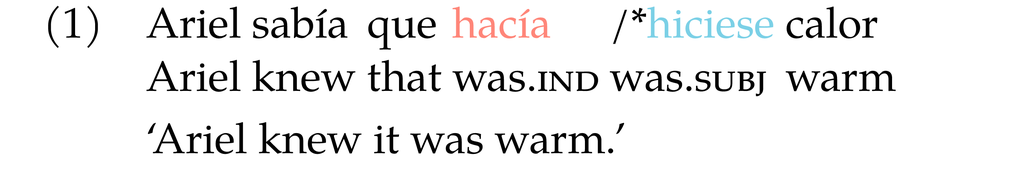

- However, when negated, the embedded verb can take indicative or subjunctive mood, a phenomenon known as Polarity Subjunctive (Quer 1998):

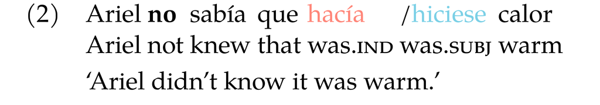

## 📚 Presuppositional Account

- Indicative presupposes that the speaker is committed to *p*, whereas subjunctive does not trigger such presupposition (Alonso 1999):

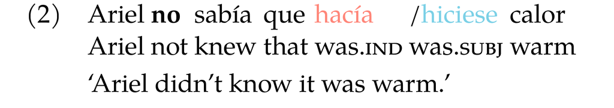

| Embedded Mood | Asserts | Presupposes |
| --- | --- | --- |
| ind | Ariel didn’t know it was warm | $\leadsto$ it was warm |
| subj | Ariel didn’t know it was warm | – |

## 📚 The First Person Effect

- **No Mood Alterntion**<sup>1</sup>: 1st person matrix subject + present tense matrix verb (Alonso 1999, 3222–23; Quer 1998, 61–62)

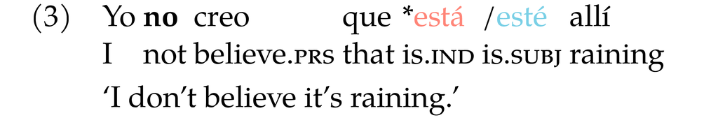

- **Presupositional Account**: indicative in (3) is ungrammatical because it leads to a semantic contradiction
  - Sentence (3) asserts: I don’t believe it is raining
  - Sentence (3) with indicative presupposes: I believe it is raining
[^1]: The sentence improves in corrective contexts (e.g. I don’t believe p, but q)

## ⚠️ A Problem with the Presuppositional Account

- Recent experimental data (Montero and Romero 2023) shows that the **presuppositional difference** only emerges (is significant and large size) with **cognitive-factive verbs**:
- V1 (cognitive-factives): *know*, *notice*, *remember*, *see* and *find out*.
- V2 (non-factive/non-fiction): *believe*, *think*, *say*, *tell* and *suspect*.
- V3 (fiction): *dream*, *fantasize*, *invent*, *fake* and *make believe*.

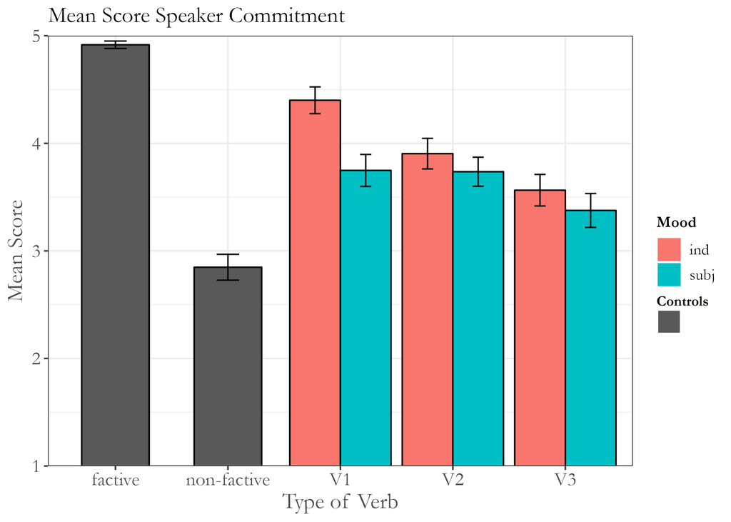

## ❔ Research Questions

1. **Is there a semantic difference in cases of mood alternation after negated non-factive verbs?**
   - Variational specialization (Wallenberg 2019): no.
2. **How can we formally characterize the alternation?**
- Competing Grammars (Kroch 1989): G1 is semantic selection, and G2 is case marking at the clausal level (Uriagereka 1988).
3. **What causes the First Person Effect with the verb *believe*?**
   - Multiple linguistic changes: first person constructions are affected by two linguistic changes; non-first person constructions are only affected by one change.

## Is there a semantic difference in cases of mood alternation after negated non-factive verbs?

**Neg-Raising**

(Reider 1990)

**Focus**

(Borgonovo 2003)

**Information Structure**

(Faulkner 2021)

**Model Shift**

(Quer 1998)

**Emotive**

(Baunaz and Puskás 2022)

**Veridicality**

(Giannakidou 2009)

## 💡 Towards a new proposal

- What if the alternation does not have a clear semantic contrast? How can we prove that?
- Evidence of absence fallacy: experimentally one can prove the existence of a given meaning, but cannot prove the absence of meaning.
- Variational Specialization: (Wallenberg 2019)

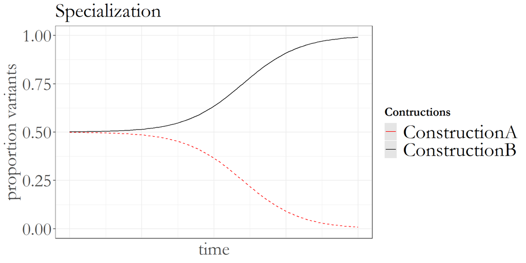

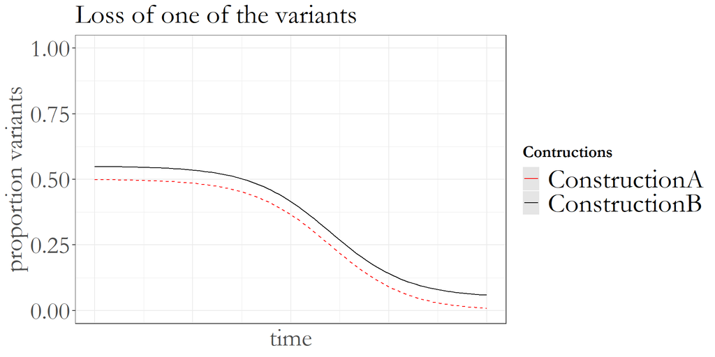

## 📉 Corpus Study

*Corpus del Diccionario histórico de la lengua española* (CNDHE)

Search

- not [believe/say/know/see] that
- 12th-20th
- published in Spain (to avoid dialectal effects)
- Total tokens: 12.360

Annotation

- Mood in the embedded clause
- Matrix Subject (first or other)
- Tense of the matrix verb
- Mood matrix verb
- declarative/interrogative

## 📉 Results

- Plot
- Data

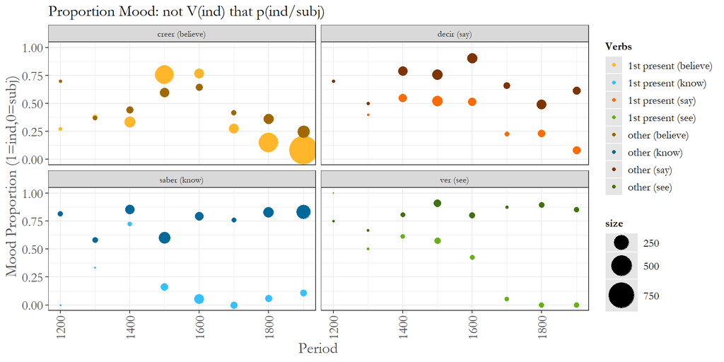

| Period | Persona | Mverbl | whet | n |
| --- | --- | --- | --- | --- |
| 1200 | 1st present (believe) | creer (believe) | 0.27272727 | 11 |
| 1200 | 1st present (know) | saber (know) | 0.00000000 | 2 |
| 1200 | 1st present (see) | ver (see) | 1.00000000 | 1 |
| 1200 | other (believe) | creer (believe) | 0.70000000 | 10 |
| 1200 | other (know) | saber (know) | 0.81481481 | 27 |
| 1200 | other (say) | decir (say) | 0.70000000 | 10 |
| 1200 | other (see) | ver (see) | 0.75000000 | 4 |
| 1300 | 1st present (believe) | creer (believe) | 0.37500000 | 24 |
| 1300 | 1st present (know) | saber (know) | 0.33333333 | 3 |
| 1300 | 1st present (say) | decir (say) | 0.40000000 | 5 |

[output cut: 53 more lines]

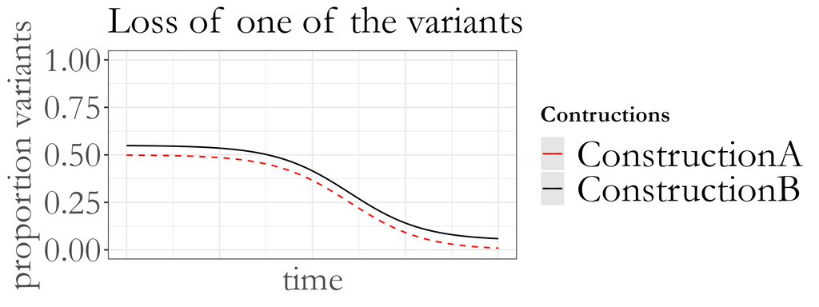

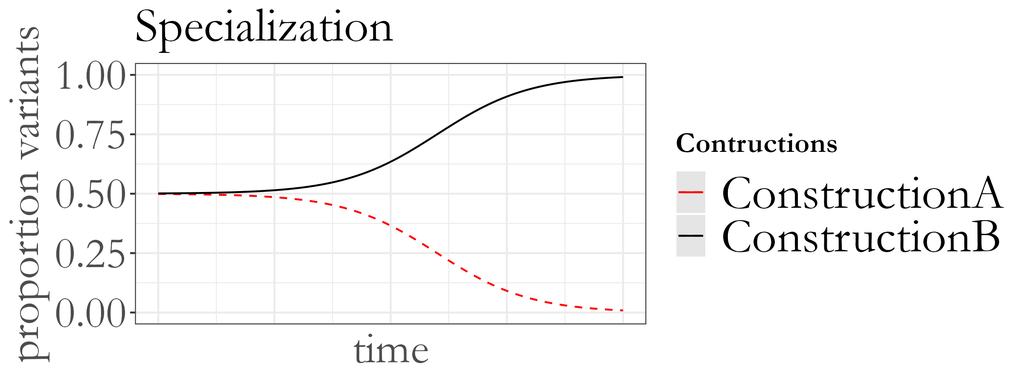

## ⚠️ Potential Problem

- Plot
- Data

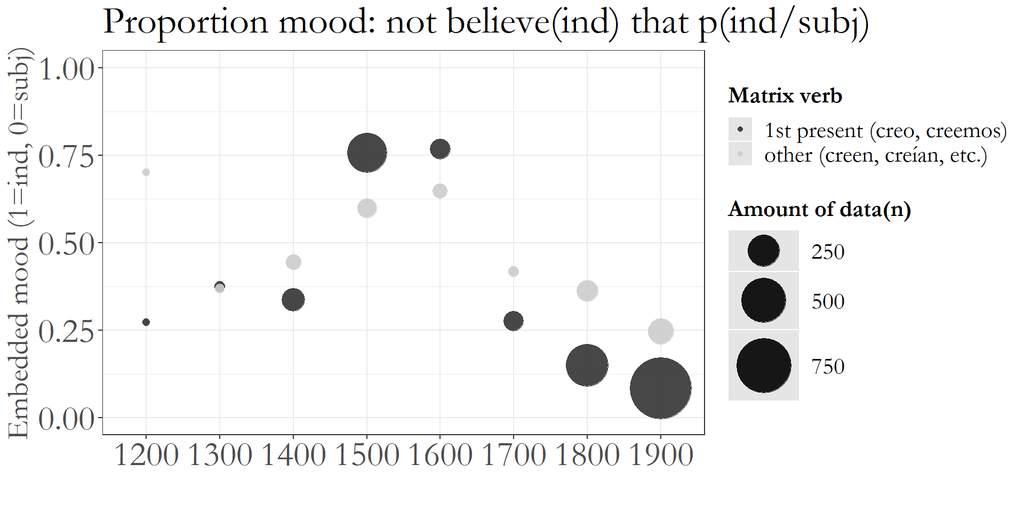

| Period | Persona | whet | n |
| --- | --- | --- | --- |
| 1200 | 1st present (creo, creemos) | 0.27272727 | 11 |
| 1200 | other (creen, creían, etc.) | 0.70000000 | 10 |
| 1300 | 1st present (creo, creemos) | 0.37500000 | 24 |
| 1300 | other (creen, creían, etc.) | 0.36842105 | 19 |
| 1400 | 1st present (creo, creemos) | 0.33587786 | 131 |
| 1400 | other (creen, creían, etc.) | 0.44444444 | 54 |
| 1500 | 1st present (creo, creemos) | 0.75757576 | 396 |
| 1500 | other (creen, creían, etc.) | 0.59782609 | 92 |
| 1600 | 1st present (creo, creemos) | 0.76699029 | 103 |
| 1600 | other (creen, creían, etc.) | 0.64705882 | 51 |

[output cut: 6 more lines]

- For the verb believe although indicative is dropping after 1600, there is an increase in the use of indicative during 1200-1500$\rightarrow$ Looks more like a failed change !

## Failed Changes

- Postma (2010) and Bacovcin (2017) have proposed to analyze failed changes as the result of two opposing successful changes (multiplication of logistics):

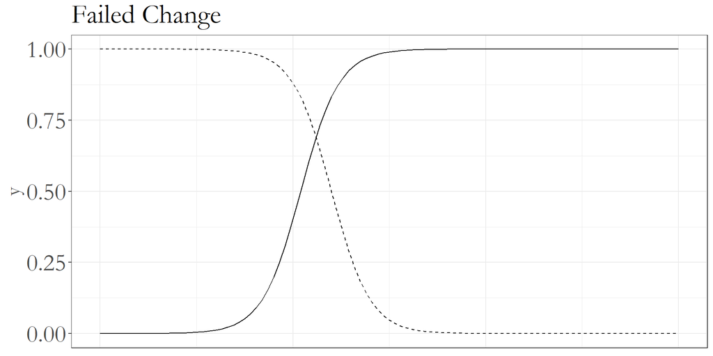

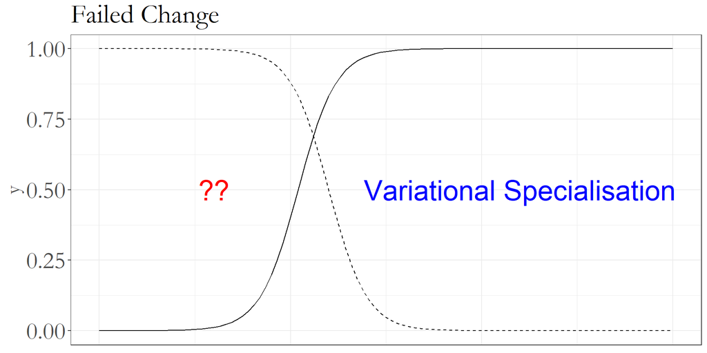

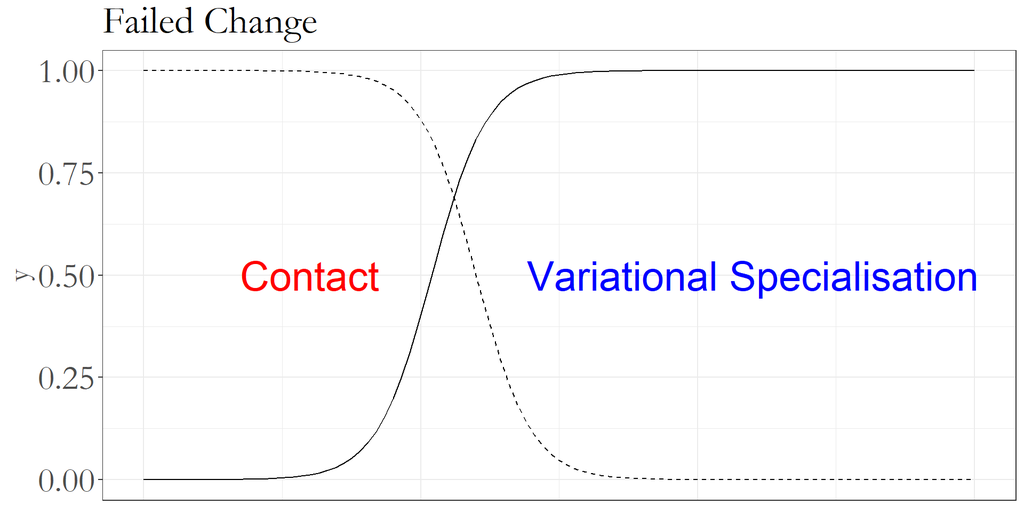

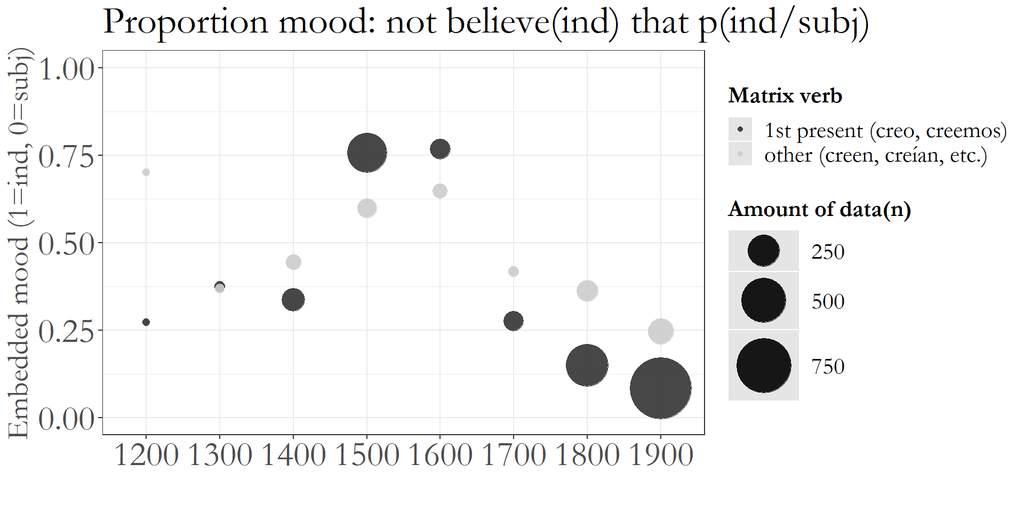

- Contact with Andalusi Romance/Arabic: goes from the conquest in 711 to the expulsion of the Moriscos in 1610 (Ruhstaller and Gordón Peral 2017).

## How can we formally charaterize the alternation after non-factive verbs?

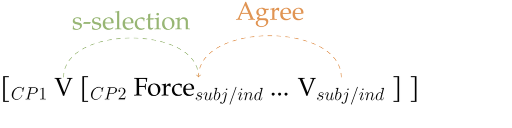

## 💡 Competing Grammars (Kroch 1989)

- **G1**: Semantics accounts like Schlenker(2003) and Giorgi $\&$ Pianesi(1997) $\longrightarrow$ indicative

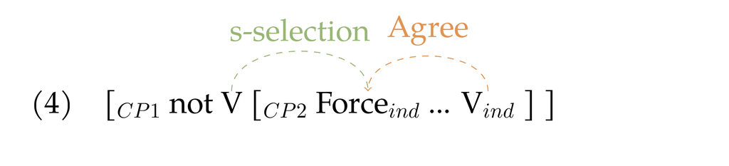

- **G2**: Subj is the equivalent of genitive/partitive case at the clausal level (Artiagoitia and Elordieta 2016; Uriagereka 1988; Kagan 2012)

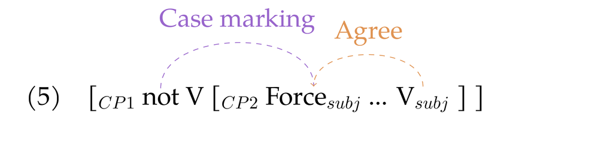

## 📚 G2: Mood as a Case Marker

- Genitive of Negation in Polish (Błaszczak 2001)

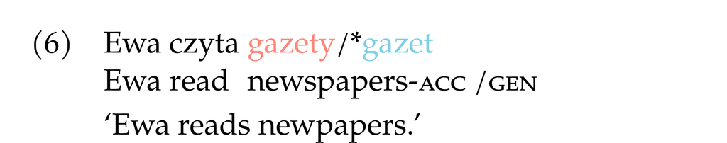

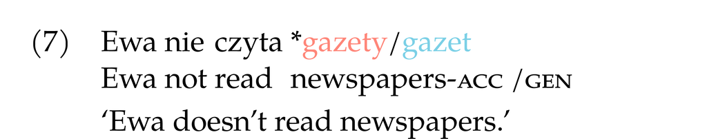

- Parallelim between GoN and Mood (Kagan 2012):

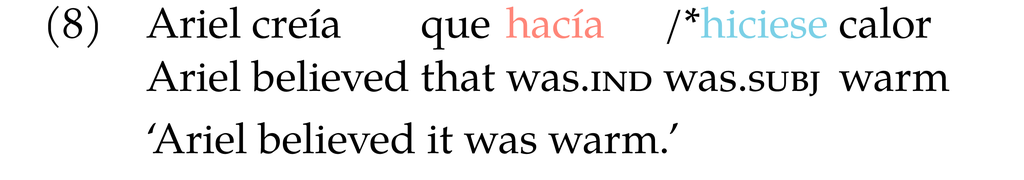

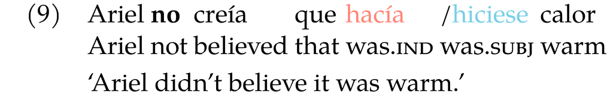

## 📚 Genitive of Negation

- This phenomenon has been analysed as a Case-Agreement relation (Błaszczak 2001). If polarity is positive the DP is valued as accusative, if negative as genitive:

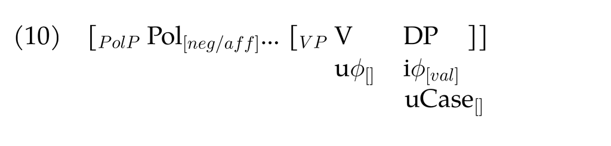

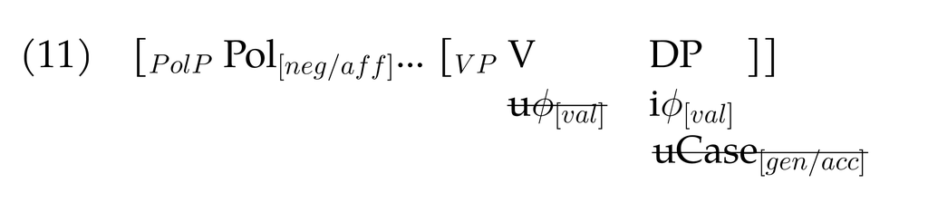

## 📚 G2: Mood as a Case Marker

- Since clauses also trigger verb-subject agreement, we argue they also carry i$\phi$-features:
10. [[That the march should go ahead] and [that it should be canceled]] have been argued by the same people at different times. (McCloskey, 1991:564)
- The derivation would proceed as follows:

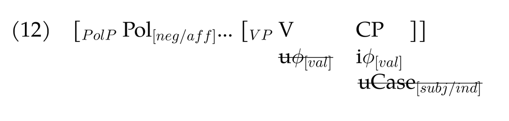

## What causes the First Person Effect with the verb *believe*?

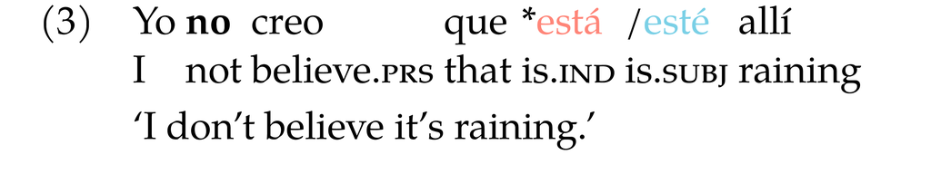

## 💡 Rate of Change: Multiple Linguistic Changes

$\dfrac{dN}{dt}=\color{#5F9EA0}{r}\cdot N$

🐠

r = birth

$\Downarrow$

Mood

r = linguistic change 1

Non-first person constructions

🐠

r = birth - death + migrations …

$\Downarrow$

Mood

r = linguistic change 1 + linguistic change 2

First person constructions

$\color{#5F9EA0}{r_{non1st}}$ < $\color{#5F9EA0}{r_{1st}}$:

**Created the asymmetry that we see in the present day language**

## 💡 Multiple linguistic changes

- Linguistic Change 1: type of mood selection

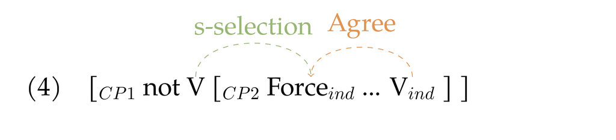

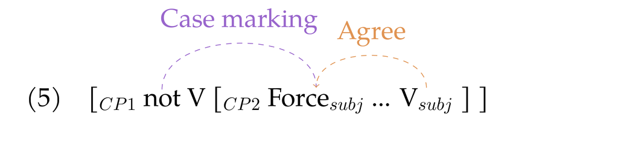

- Linguistic Change 2: where the CP is merged in the structure (Torrego and Uriagereka 1992)

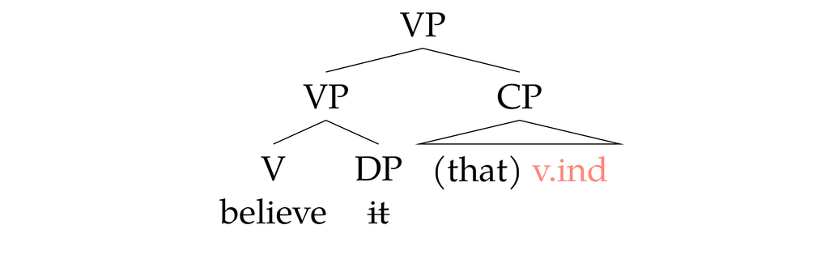

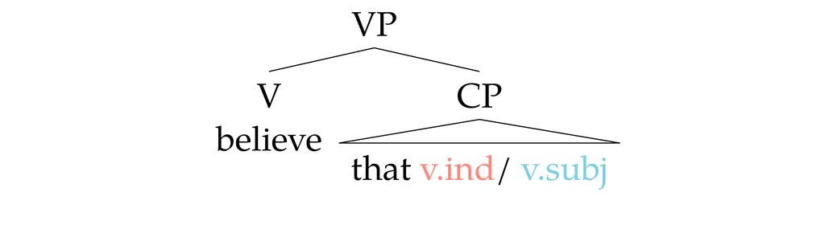